# 6_22_2020_2prongapproach

Ethan Ashby

6/19/2020

# Overview

Last time, we saw that genes with high coefficients of variance tended to be hotspot genes, i.e. genes that accumulated large numbers of the same variants because these variants conferred a competitive advantage to the tumor celll. Thus, these genes tended to have more high-Nr mutations, relatively low numbers of singletons, and therefore higher coefficients of variation.

The goal this time around was to see if these genes with high coefficients of variance reflect any similar patterns or display heterogeneity in the reasons why their cofficients of variance were so high.

As we relaxed the mutation threshold cutoff, we saw more and more genes get included, and the threshold for the problematic region increase, although we were concerned that large values would tend to overwhelm when looking at the plot.

We figured we needed an easier to interpret metric, so MSK-IMPACT probabilities were collected to assess the accuracy of Good-Turing predictions.

Lastly, we were interested in whether metafeatures could be used to predict coefficient of variation.

# Delving into small cohort

In the small cohort of genes (mutation thresh>0.03), barplots and density plots of the coefficients of variance show a slight right skewed distribution, with 6 genes showing higher variance. What is driving these higher variances?

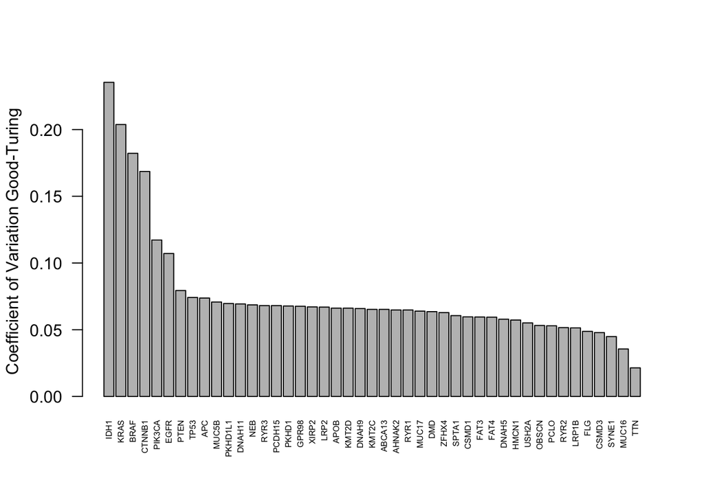

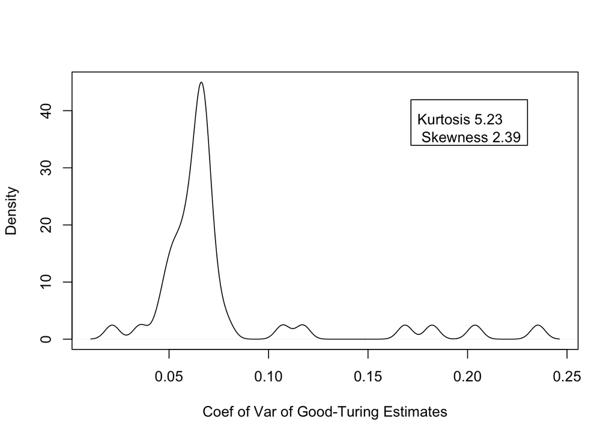

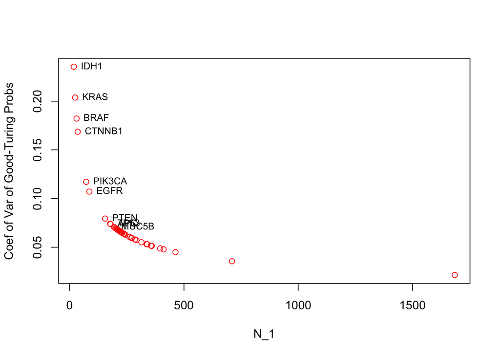

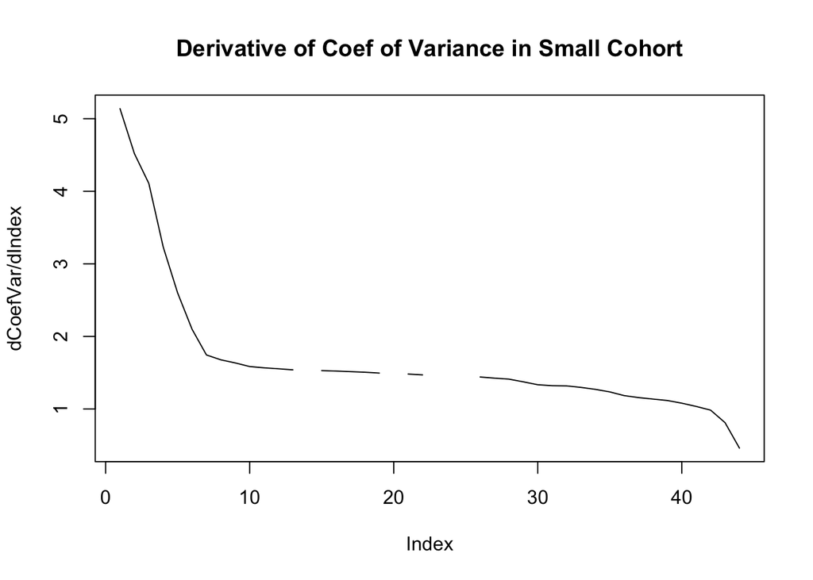

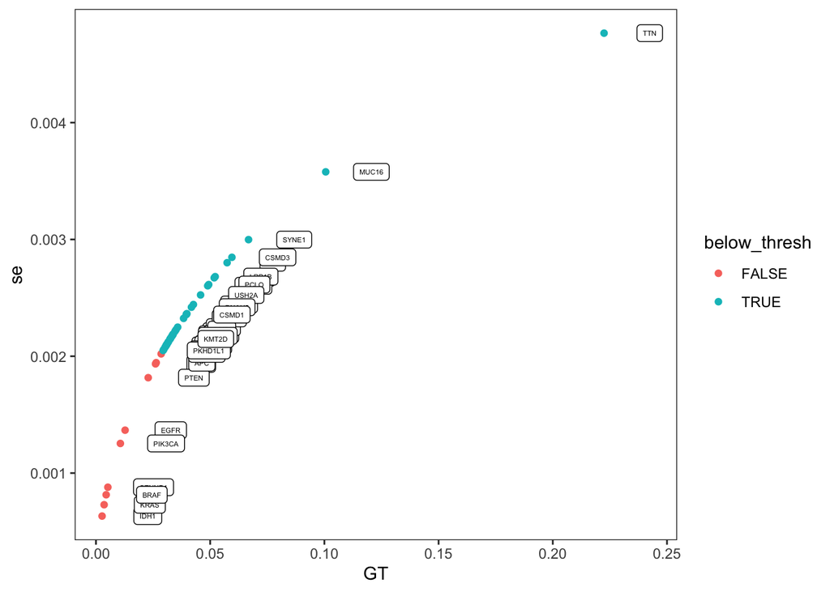

# MSK-IMPACT Validation

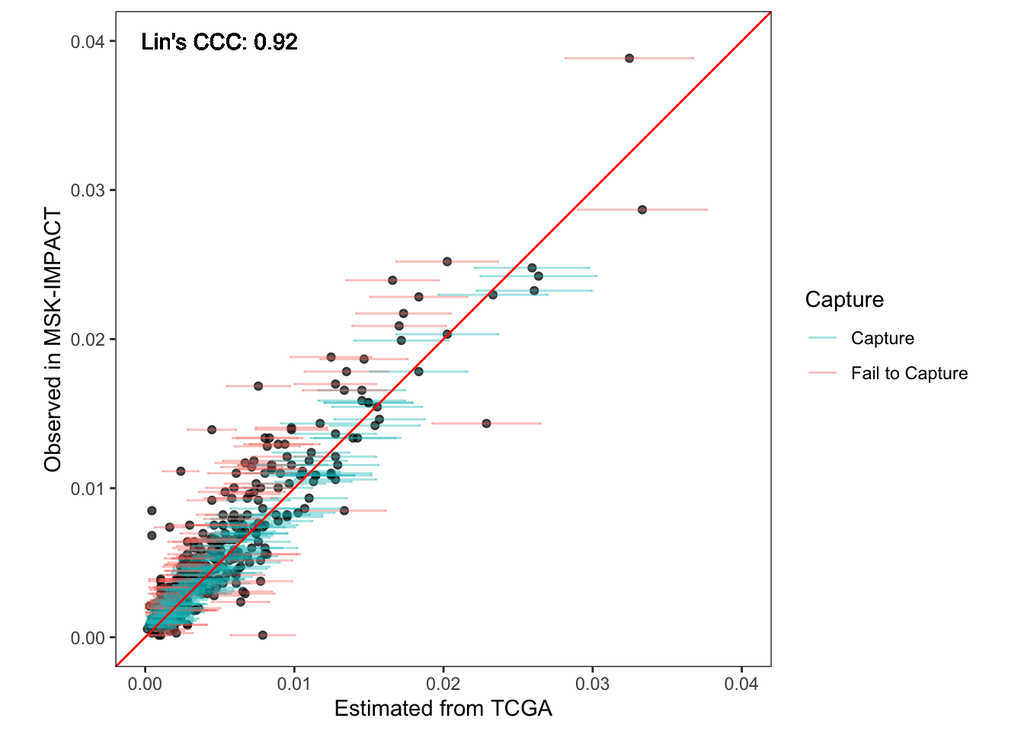

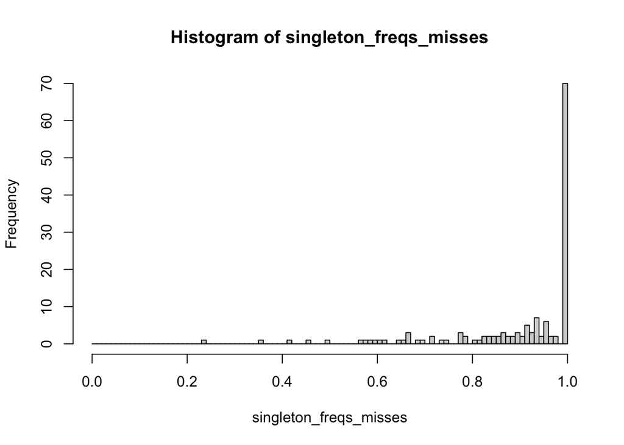

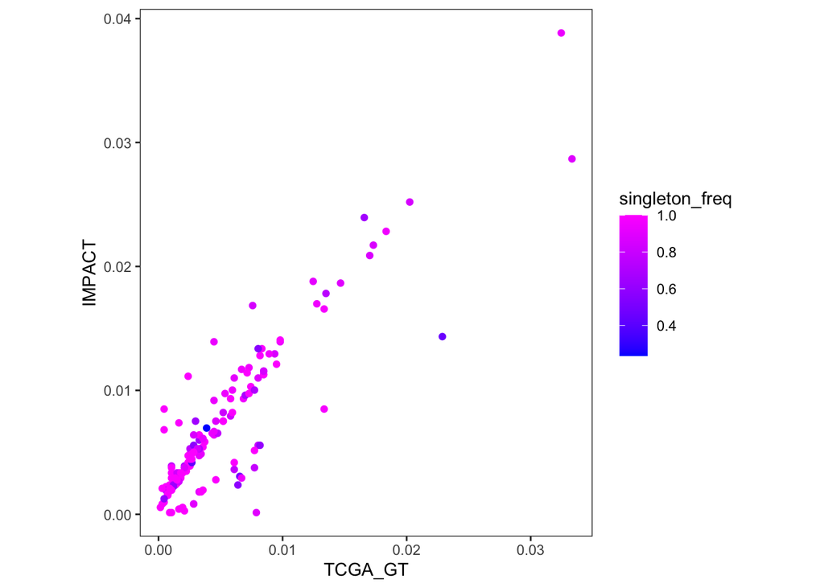

0.64 of genes in the MSK impact cohort had Good-Turing probability confidence intervals that captured the probability of observing a new variant in the MSK-IMPACT sequencing study. Of those intervals that did not capture the MSK-IMPACT values, 0.83 of IMPACT probabilities were greater than those estimated from TCGA. Of these misses 0.4794521 were composed exclusively of singletons.

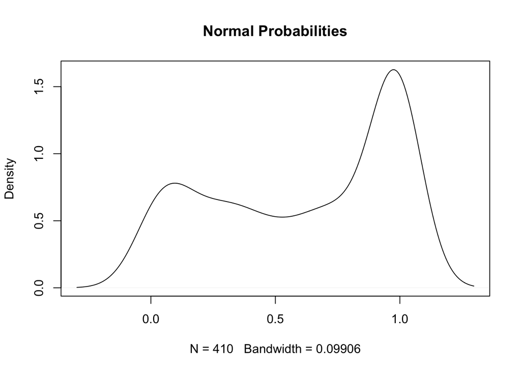

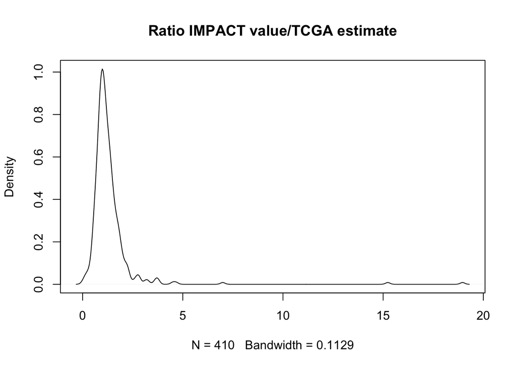

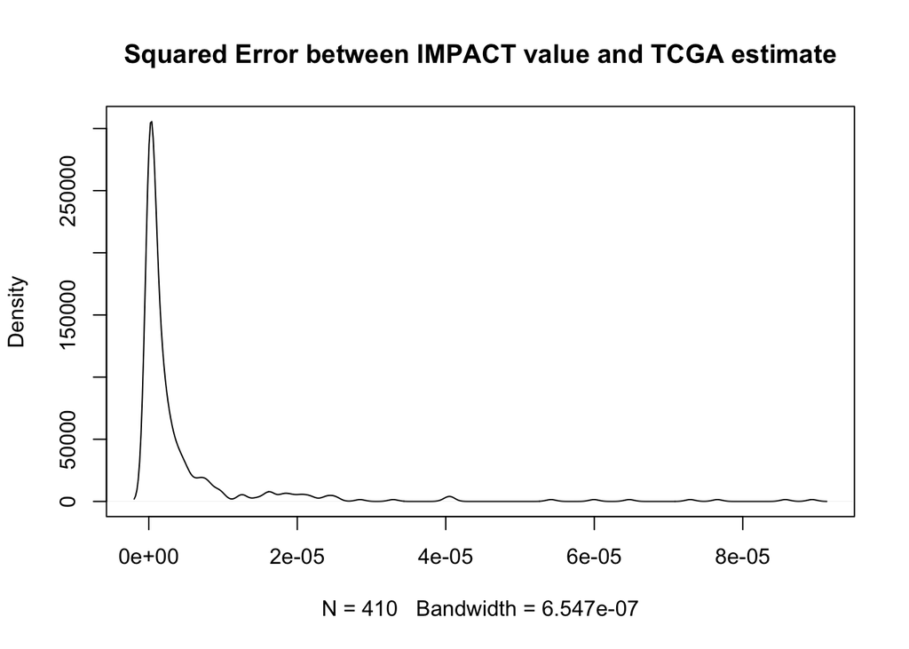

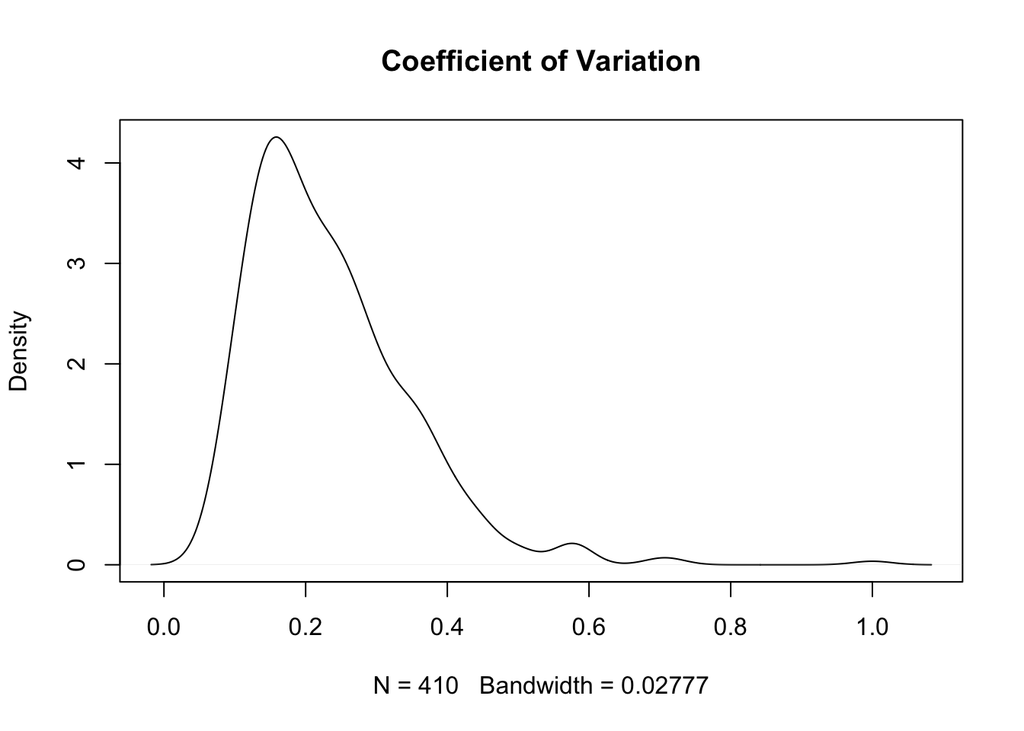

# Revisiting the metafeature construction

Do any of these metafeatures carry any signal vis-a-vis Good-Turing probabilities? For genes in the MSK-IMPACT cohort, I generated a scatterplot matrix of the 5 single-variable metafeatures with known correlations to somatic mutation rate: expression, replication time, noncoding mutation rate, local GC content, and HiC compartment. The most significant correlation was between HiC compartment and the Good-Turing probability and SE estimates generated from the TCGA data. Admittedly, all correlations were small and there was no clear trend between any of these metafeatures and the Good-Turing estimates.

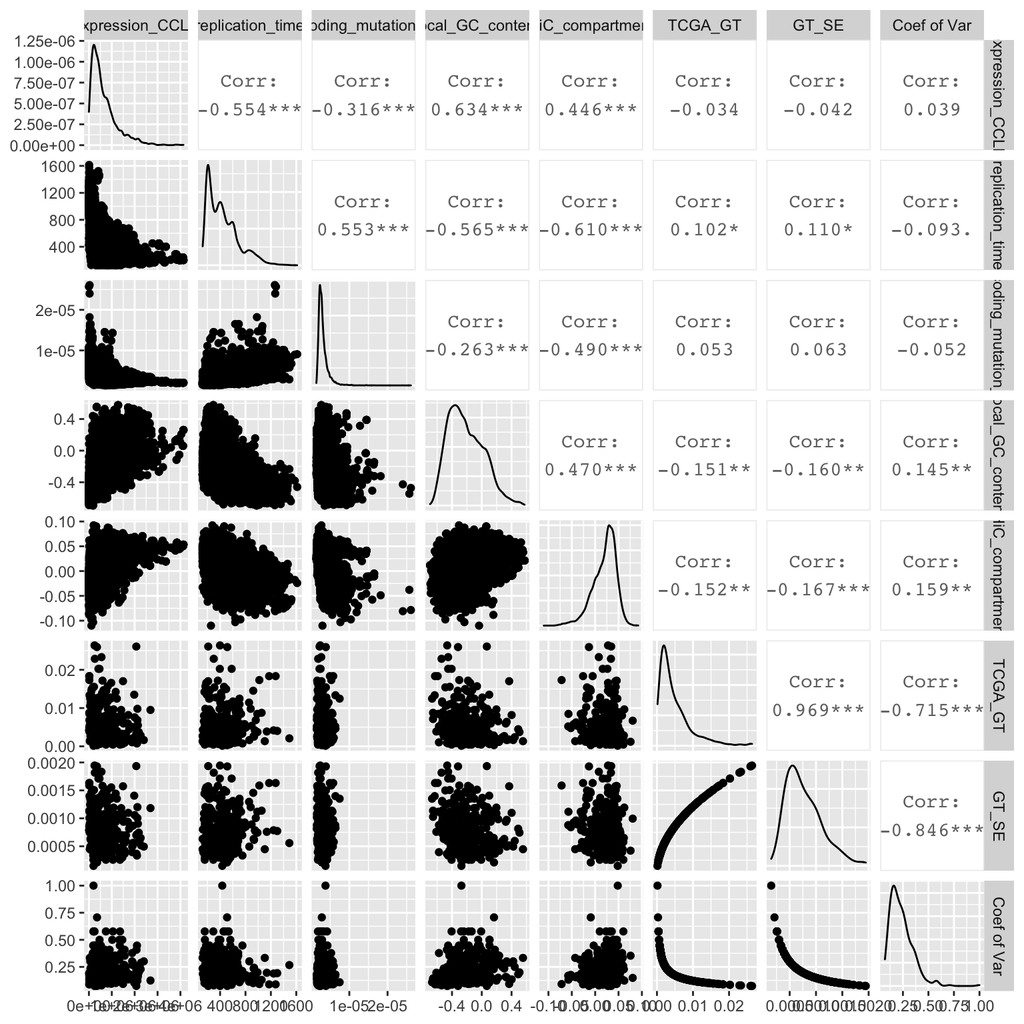